# Loan Prediction Machine Learning Project

## QDA Model

Now, let’s analyze our quadratic discriminant analysis (QDA) classifier. Essentially, QDA is an advanced version of the LDA model, used to identify non-linear decision boundaries between classes, with the assumption that each class follows a Gaussian distribution.

### Testing the model

To my surprise, the QDA model outperformed the KNN model, though its computed `roc_auc` score is only slightly higher. Nevertheless, a 0.02-point increase in AUC is quite significant, especially in this context.

```r
qda_roc_auc <- augment(qda_fit, new_data = loan_test, type = 'prob') %>%
  roc_auc(Loan_Status, .pred_Yes) %>%
  select(.estimate)

qda_roc_auc
```

| .estimate |
| --- |
| 0.668341 |

### ROC curve

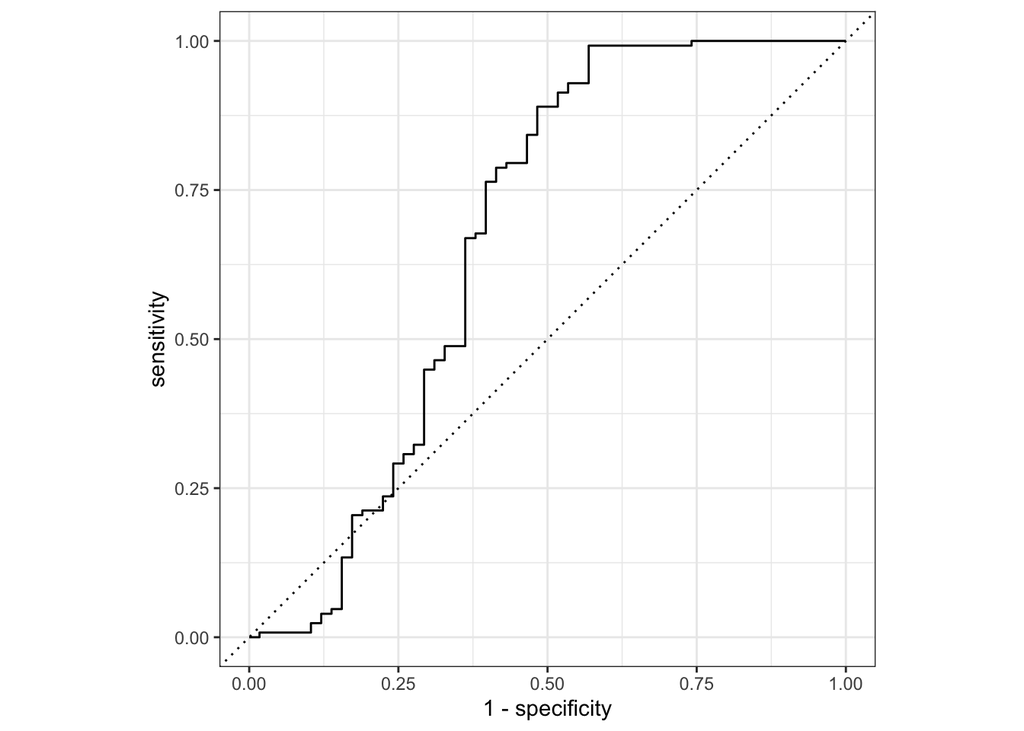

```r
augment(qda_fit, new_data = loan_test, type = 'prob') %>%
  roc_curve(Loan_Status, .pred_Yes) %>%
  autoplot()
```

## Elastic Net

Lastly, we will explore the results of the elastic net model. First, let’s compute its `roc_auc` score and then create visualization as needed.

### Testing the model

```r
en_roc_auc <- augment(en_final_fit, new_data = loan_test, type = 'prob') %>%
  roc_auc(Loan_Status, .pred_Yes) %>%
  select(.estimate)

en_roc_auc
```

| .estimate |
| --- |
| 0.7265816 |

### ROC curve

Its ROC curve looks much better than that of the KNN model, and is an improvement from the QDA model as well. From approximately 0.5 specificity onward, sensitivity sits near 1.0. This is a good sign!

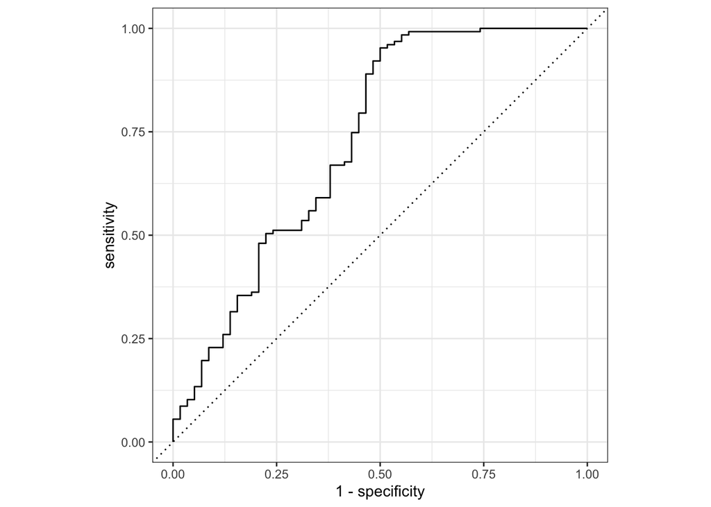

```r
augment(en_final_fit, new_data = loan_test, type = 'prob') %>%
  roc_curve(Loan_Status, .pred_Yes) %>%
  autoplot()
```

# Conclusion

In this project, we tackled the problem of loan prediction given select demographics specified in applicant profiles. Working with a relatively small dataset with a large number of features, we followed a systematic approach: tidying the data, conducting exploratory analysis, and fitting 6 models of varying complexity and flexibility. Through analysis, testing, and assessment, we found the elastic net model to be most optimal for predicting the loan status of an applicant. However, the model was not perfect and leaves room for improvement.

In fact, none of our models performed exceptionally well for this task, which can be attributed to various factors such as assumption violations and overfitting. None of the models considered were particularly robust in preventing overfitting (with the exception of elastic net).

Models like logistic regression and LDA assume linear decision boundaries, which became problematic in higher dimensions. Elastic net (Ridge) was efficient in variance reduction but introduced more bias. The QDA model, while an improvement from LDA and logistic, is less flexible than methods like KNN and decision trees. For more complex decision boundaries, a non-parametric approach may be preferred. Decision trees, while powerful, are highly variant and are prone to overfitting. KNN doesn’t require linear separability and makes no distributional assumptions; however, it does not model relationships very well and also tends to overfit.

Given the relatively better performance of the QDA and elastic net models on the test set, we can infer that the relationships in our data are non-linear. Future improvements could involve exploring other non-linear models or incorporating non-linear extensions to the models considered. Additionally, non-parametric approaches may offer an advantage in capturing more complex decision boundaries.

As far as our error metric (as measured by `roc_auc`), the EN model outperformed the QDA model on the test set despite underperforming on the training set. It is worth noting that both models did not have particularly high predictive accuracy (both around 0.7), likely due to their limitations in dimensional reduction. A more flexible model, such as a random forest, could improve accuracy by reducing redundant features and noise.

It is important to note that none of our models performed particularly poorly either. Loan prediction is inherently challenging, and predictive models are often sensitive to nuisance factors and noise. Our dataset was incomplete, and the exclusion of potentially important features such as applicant age or race might have limited our ability to capture the target demographic. Including these factors could not only improve prediction accuracy but also reveal potential implicit biases in lending practices. With this understanding, assigning a class label to each applicant based on a select few demographics seem unfair. Instead, applicants should be assessed on a case-by-case basis.

[figure not shown]